# R code for Figure 3 - figure supplement 2 - Comparative analysis supporting figures

Xiao Xu (xxu@rockefeller.edu)

June 2018

Xu X, Stoyanova EI, Lemiesz A, Xing J, Mash DC, Heintz N (2018). Species and Cell-Type Properties of Classically Defined Human and Rodent Neurons and Glia.

Specifically, this workflow will generate the heatmap to accompany IGV tracks and figures relating to length and GC bias in mouse human comparative analysis.

Load libraries and functions:

```r
# source custom functions
source("functions.R")
# libraries for heatmaps and colors
library(RColorBrewer)
library(gplots)
# libraries for plotting
library(grid)
library(gridExtra)
# libraries for genome analysis
library(GenomicRanges)
library(rtracklayer)
library(Rsamtools)
# libraries for data manipulation
library(reshape2)
# work in the tidyverse
library(tidyverse)
```

## Heatmap to accompany IGV tracks

Import counts and create metadata

```r
# read in table of counts
counts <- read_tsv("../data/rat_all_wg_counts.txt") %>%
  select(-contains("uns"), -contains("purkinje"))
meta <- tibble(
  Sample = colnames(counts)[-1],
  Cell_type = rep(
    c("Granule", "Basket", "Astrocyte", "Oligo", "OPC"),
    each = 2
    )
  )
```

Normalize counts by length using FPKM (RPKM) calculation:

```r
# read in gene lengths
lengths <- read_tsv("../data/ref/rat_ensembl_wg_lengths.txt",
                    col_names = c("Gene", "Length"))
# calculate rpkms
rpkms <- getNormCounts(counts, lengths, type = "RPKM")
```

```
Setting row names on a tibble is deprecated.
```

Genes to visualize

```r
igv_genes <- c("Fat2", "Vwc2", "Cnksr3",
               "March11", "Lmcd1", "Mpp7",
               "Slc1a3", "Rgcc", "Mybpc1",
               "Mog", "Gldn", "Kcnk13",
               "Pdgfra", "Scn9a", "Lpcat2")
rpkms_for_igv <- rpkms[igv_genes, ] %>% t()
```

Specify colors for heatmap:

```r
# palette for z-scores
cor_col <- colorRampPalette( brewer.pal(9, 'YlOrRd') )(100)
cor_breaks <- seq(-2, 10, length.out = 101)
# sidebar for heatmap.2
cell_type_cols <- c(
  Granule = "#33A02C",
  Basket = "#FF6600",
  Astrocyte = "#0033FF",
  Oligo = "#00CCCC",
  OPC = "#00FFFF"
)
sidebar_row <- rep(cell_type_cols, each = 2)
sidebar_col <- rep(cell_type_cols, each = 3)
```

Plot heatmap:

```r
pdf("../figures/figure_3_s2_heatmap_rat_for_igv.pdf", width = 11, height = 8.5)
hm <- heatmap.2(
  rpkms_for_igv,
  dendrogram = "none", Rowv = FALSE, Colv = FALSE, # no dendrogram, no reordering
  col = cor_col, breaks = cor_breaks,  # colors for values
  RowSideColors = sidebar_row, ColSideColors = sidebar_col,  # sidebar
  scale = "none", trace = "none",
  key.title = NA, key.ylab = NA,
  cexRow = 1, cexCol = 1, margins = c(2, 2),
  labCol = FALSE, labRow = FALSE, symkey = F,
  keysize = 1, key.par = list(mar = c(4, 2, 1, 1))
)
dev.off()
```

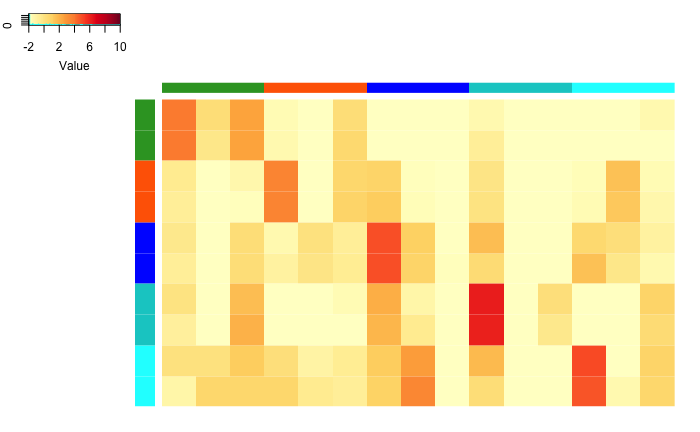

```r
# and display in this file
eval(hm$call)
```

## Length and GC bias

### Get genome features

Load and prepare annotation files. Download fa files from Ensembl.

```r
# define files
species <- c("mouse", "human")
annot_files <- tibble(
  Species = species,
  GTF = c("../data/ref/mm10_ortho_to_hg38_wg.gtf",
          "../data/ref/hg38_ortho_to_mm10_wg.gtf"),
  Fasta = c("../data/ref/fasta/Mus_musculus.GRCm38.r88_scaffold_chr.fa",
            "../data/ref/fasta/Homo_sapiens.GRCh38_r88_scaffold_chr.fa")
)
# load and reduce gtf anootation
gtfs <- list(
  mouse = reduceGTF(
    annot_files %>% filter(Species == "mouse") %>% pull(GTF),
    genome = "GRCm38.88",
    feature = "wg"
    ),
  human = reduceGTF(
    annot_files %>% filter(Species == "human") %>% pull(GTF),
    genome = "GRCh38.88",
    feature = "wg"
    )
)
```

Load species enriched genes.

```r
cell_types <- c("Granule", "Basket", "Astrocyte", "Oligo", "OPC")
se_genes <- lapply(cell_types,
                   function(x)
                     read_tsv(
                       paste("../output/figure_3_main_species_de_mouse_human_",
                             tolower(x), ".txt", sep = "")
                       ) %>%
                     mutate(Gene_human = convertIDs(Gene)) %>%
                     mutate(Type = ifelse(log2FoldChange > 0, "mouse", "human")) %>%
                     mutate(Gene_host = ifelse(log2FoldChange > 0, Gene, Gene_human)) %>%
                     mutate(Gene_conv = ifelse(log2FoldChange > 0, Gene_human, Gene)) %>%
                     mutate(Cell_type = x) %>%
                     select(Gene = Gene_host, Gene_conv, Type, Cell_type)
                   ) %>%
  bind_rows() %>%
  distinct(Gene, .keep_all = TRUE)
# create lookup table for later
lookup <- se_genes$Cell_type
names(lookup) <- se_genes$Gene
```

Get genomic summary including GC content and gene length for 4 classes of genes: * mouse-enriched genes in mouse * human-enriched genes in mouse * mouse-enriched genes in human * human-enriched genes in human Also get genomic summary for all mouse and human genes

```r
# sumamry for species enriched genes
genomic_sum <- sapply(
  species,
  function(host) sapply(
    c("all", species),
    function(enr) {
      # subset gtf
      host_gtf <- gtfs[[host]]
      if(enr == "all") {
        gtf_sub <- host_gtf
      } else if(enr == host) {
        gtf_sub <- host_gtf[
          elementMetadata(host_gtf)[, 1] %in%
            (se_genes %>% filter(Type == enr) %>% pull(Gene))
          ]
      } else{
        gtf_sub <- host_gtf[
          elementMetadata(host_gtf)[, 1] %in%
            (se_genes %>% filter(Type == enr) %>% pull(Gene_conv))
          ]
      }
      # return length and gc content
      return(
        getGC(gtf_sub, annot_files %>% filter(Species == host) %>% pull(Fasta)) %>%
          mutate(Host = host, Type = enr, Gene = elementMetadata(gtf_sub)[, 1])
        )
      },
    simplify = FALSE, USE.NAMES = TRUE
    ),
  simplify = FALSE, USE.NAMES = TRUE
  )
```

Reshape data for plotting

```r
genomic_sum_df <- genomic_sum %>%
  reduce(bind_rows) %>%
  mutate(Gene = ifelse(Host == "mouse", Gene,
                       convertIDs(Gene, from = "human", to = "mouse")))
genomic_length <- genomic_sum_df %>%
  select(-GC) %>%
  spread(key = Host, value = Length)
genomic_length_se <- genomic_length %>%
  filter(Type != "all") %>%
  mutate(Cell_type = ifelse(Type == "mouse", lookup[Gene], lookup[convertIDs(Gene)]))
```

Match up mouse and human values for gene length and GC content

```r
genomic_length <- genomic_sum_df %>%
  select(-GC) %>%
  spread(key = Host, value = Length)
genomic_length_se <- genomic_length %>%
  filter(Type != "all") %>%
  mutate(Cell_type = ifelse(Type == "mouse", lookup[Gene], lookup[convertIDs(Gene)]))
genomic_gc <- genomic_sum_df %>%
  select(-Length) %>%
  spread(key = Host, value = GC)
genomic_gc_se <- genomic_gc %>%
  filter(Type != "all") %>%
  mutate(Cell_type = ifelse(Type == "mouse", lookup[Gene], lookup[convertIDs(Gene)]))
```

Linear regression to find relationship between mouse and human gene length or GC content for all genes

```r
lm_length <- lm(log10(human) ~ log10(mouse),
                data = filter(genomic_length, Type == "all")) %>%
  coefficients()
lm_gc <- lm(human ~ mouse, data = filter(genomic_gc, Type == "all")) %>%
  coefficients()
```

### Plots

Plot mouse vs human gene length and GC content. Arrange plots, save to file, and display here

```r
lims_gc <- c(0.3, 0.75)
g <- arrangeGrob(
  plotAllByFeature(genomic_length,
                   slope = lm_length[2],
                   intercept = lm_length[1]),
  plotSEByFeature(genomic_length_se %>% filter(Type == "mouse"),
                  slope = lm_length[2],
                  intercept = lm_length[1]),
  plotSEByFeature(genomic_length_se %>% filter(Type == "human"),
                  slope = lm_length[2],
                  intercept = lm_length[1]),
  plotAllByFeature(genomic_gc, lims = lims_gc, log_scale = FALSE,
                   slope = lm_gc[2],
                   intercept = lm_gc[1]),
  plotSEByFeature(genomic_gc_se %>% filter(Type == "mouse"),
                  lims = lims_gc, log_scale = FALSE,
                  slope = lm_gc[2],
                  intercept = lm_gc[1]),
  plotSEByFeature(genomic_gc_se %>% filter(Type == "human"),
                  lims = lims_gc, log_scale = FALSE,
                  slope = lm_gc[2],
                  intercept = lm_gc[1]),
  ncol = 3
  )
ggsaveToPdf(
  paste("../figures/figure_3_s2_mouse_vs_human_length_gc.pdf", sep = ""),
  plot = g, w = 14, h = 6
  )
grid.newpage()
```

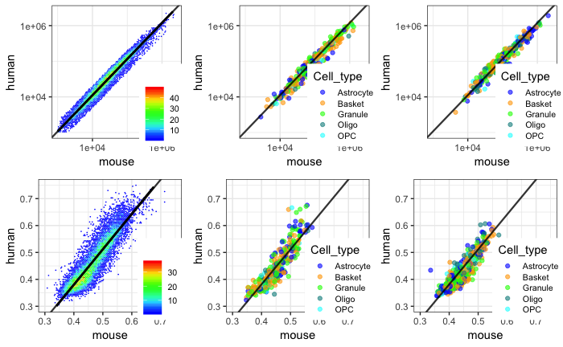

```r
grid.draw(g)
```

### GC content vs log2 fold change

Create plots

```r
gc_plots <- lapply(
  species,
  function(s) {
    ps <- lapply(
      cell_types,
      function(ct)
        plotFCAgainstGC(ct, genomic_sum_df %>% filter(Type == "all", Host == s))
      )
    names(ps) <- cell_types
    return(ps)
  }
  )
names(gc_plots) <- species
```

Arrange plots, save to file, and display here

```r
g <- arrangeGrob(
  gc_plots[["mouse"]][["Granule"]], gc_plots[["mouse"]][["Basket"]],
  gc_plots[["mouse"]][["Astrocyte"]], gc_plots[["mouse"]][["Oligo"]],
  gc_plots[["mouse"]][["OPC"]], gc_plots[["human"]][["Granule"]],
  gc_plots[["human"]][["Basket"]], gc_plots[["human"]][["Astrocyte"]],
  gc_plots[["human"]][["Oligo"]],gc_plots[["human"]][["OPC"]],
  ncol = 5
  )
ggsaveToPdf(
  paste("../figures/figure_3_s2_fc_vs_gc.pdf", sep = ""),
  plot = g, w = 14, h = 6
  )
grid.newpage()
```

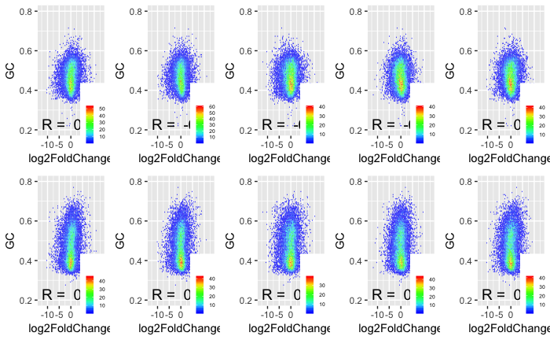

```r
grid.draw(g)
```